# Supplemental Analysis: Iris Dataset - Post-hoc Testing, MANOVA, and LDA

Phinn Markson

December 5, 2025

# Introduction

This supplemental analysis provides additional statistical testing for the Iris dataset to complement the initial analysis. The procedures include post-hoc Tukey tests for each morphological measurement, MANOVA to assess multivariate differences among species, and linear discriminant analysis (LDA) to evaluate species classification.

# Data and Methods

The Iris dataset contains four morphological measurements (sepal length, sepal width, petal length, petal width) for 150 flowers across three species (setosa, versicolor, virginica). All analyses were conducted in R.

# Post-hoc Testing: Tukey HSD

## Individual ANOVAs

Individual ANOVAs were conducted for each of the four morphological variables, followed by Tukey Honest Significant Difference (HSD) post-hoc tests to identify specific pairwise differences between species groups.

```r
# Individual ANOVAs for each variable
aov_sl <- aov(Sepal.Length ~ Species, data = iris)
aov_sw <- aov(Sepal.Width ~ Species, data = iris)
aov_pl <- aov(Petal.Length ~ Species, data = iris)
aov_pw <- aov(Petal.Width ~ Species, data = iris)

# Summary of ANOVAs
cat("=== Sepal Length ANOVA ===\n")
```

```
## === Sepal Length ANOVA ===
```

```r
summary(aov_sl)
```

```
##              Df Sum Sq Mean Sq F value Pr(>F)
## Species       2  63.21  31.606   119.3 <2e-16 ***
## Residuals   147  38.96   0.265
## ---
## Signif. codes:  0 '***' 0.001 '**' 0.01 '*' 0.05 '.' 0.1 ' ' 1
```

```r
cat("\n=== Sepal Width ANOVA ===\n")
```

```
##
## === Sepal Width ANOVA ===
```

```r
summary(aov_sw)
```

```
##              Df Sum Sq Mean Sq F value Pr(>F)
## Species       2  11.35   5.672   49.16 <2e-16 ***
## Residuals   147  16.96   0.115
## ---
## Signif. codes:  0 '***' 0.001 '**' 0.01 '*' 0.05 '.' 0.1 ' ' 1
```

```r
cat("\n=== Petal Length ANOVA ===\n")
```

```
##
## === Petal Length ANOVA ===
```

```r
summary(aov_pl)
```

```
##              Df Sum Sq Mean Sq F value Pr(>F)
## Species       2  437.1  218.55    1180 <2e-16 ***
## Residuals   147   27.2    0.19
## ---
## Signif. codes:  0 '***' 0.001 '**' 0.01 '*' 0.05 '.' 0.1 ' ' 1
```

```r
cat("\n=== Petal Width ANOVA ===\n")
```

```
##
## === Petal Width ANOVA ===
```

```r
summary(aov_pw)
```

```
##              Df Sum Sq Mean Sq F value Pr(>F)
## Species       2  80.41   40.21     960 <2e-16 ***
## Residuals   147   6.16    0.04
## ---
## Signif. codes:  0 '***' 0.001 '**' 0.01 '*' 0.05 '.' 0.1 ' ' 1
```

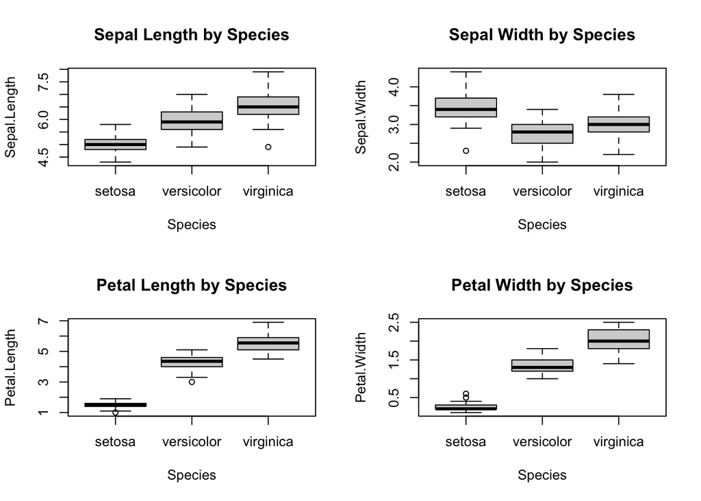

```r
par(mfrow=c(2,2))
boxplot(Sepal.Length ~ Species, data=iris, main="Sepal Length by Species")
boxplot(Sepal.Width ~ Species, data=iris, main="Sepal Width by Species")
boxplot(Petal.Length ~ Species, data=iris, main="Petal Length by Species")
boxplot(Petal.Width ~ Species, data=iris, main="Petal Width by Species")
```

```r
par(mfrow=c(1,1))
```

## Tukey HSD Results

Tukey HSD tests were conducted for each variable to identify significant pairwise differences between species.

### Chunk 1: Calculate Tukey Objects

```r
tukey_sl <- TukeyHSD(aov_sl)
tukey_sw <- TukeyHSD(aov_sw)
tukey_pl <- TukeyHSD(aov_pl)
tukey_pw <- TukeyHSD(aov_pw)
```

### Chunk 2: Build Combined Tukey Table

```r
# Function to extract Tukey results into a data frame
extract_tukey <- function(tukey_result, variable_name) {
  tukey_df <- as.data.frame(tukey_result[[1]])
  tukey_df$comparison <- rownames(tukey_df)
  tukey_df$variable <- variable_name
  tukey_df[, c("comparison", "variable", "diff", "lwr", "upr", "p adj")]
}

# Combine all results into one table
tukey_results <- rbind(
  extract_tukey(tukey_sl, "Sepal Length"),
  extract_tukey(tukey_sw, "Sepal Width"),
  extract_tukey(tukey_pl, "Petal Length"),
  extract_tukey(tukey_pw, "Petal Width")
)

# Display combined results table
knitr::kable(tukey_results,
             caption = "Tukey HSD Post-hoc Tests for Iris Dataset Variables",
             digits = 3,
             row.names = FALSE)
```

Tukey HSD Post-hoc Tests for Iris Dataset Variables

| comparison | variable | diff | lwr | upr | p adj |
| --- | --- | --- | --- | --- | --- |
| versicolor-setosa | Sepal Length | 0.930 | 0.686 | 1.174 | 0.000 |
| virginica-setosa | Sepal Length | 1.582 | 1.338 | 1.826 | 0.000 |
| virginica-versicolor | Sepal Length | 0.652 | 0.408 | 0.896 | 0.000 |
| versicolor-setosa | Sepal Width | -0.658 | -0.819 | -0.497 | 0.000 |
| virginica-setosa | Sepal Width | -0.454 | -0.615 | -0.293 | 0.000 |
| virginica-versicolor | Sepal Width | 0.204 | 0.043 | 0.365 | 0.009 |
| versicolor-setosa | Petal Length | 2.798 | 2.594 | 3.002 | 0.000 |
| virginica-setosa | Petal Length | 4.090 | 3.886 | 4.294 | 0.000 |
| virginica-versicolor | Petal Length | 1.292 | 1.088 | 1.496 | 0.000 |
| versicolor-setosa | Petal Width | 1.080 | 0.983 | 1.177 | 0.000 |
| virginica-setosa | Petal Width | 1.780 | 1.683 | 1.877 | 0.000 |
| virginica-versicolor | Petal Width | 0.700 | 0.603 | 0.797 | 0.000 |

### Chunk 3: Define Clean Plotting Function

```r
plot_tukey_clean <- function(tukey_obj, variable_name, units = "cm") {
  tuk_df <- as.data.frame(tukey_obj[[1]])
  tuk_df$comparison <- rownames(tuk_df)

  # Factor → integer positions (reversed for top-to-bottom order)
  tuk_df$comparison <- factor(tuk_df$comparison, levels = rev(tuk_df$comparison))
  y_positions <- as.numeric(tuk_df$comparison)

  # Expand left margin for y-axis labels
  par(mar = c(5, 12, 4, 2))

  plot(
    x = tuk_df$diff,
    y = y_positions,
    xlab = paste0("Difference in Mean (", units, ")"),
    ylab = "",
    pch = 19,
    cex = 1.2,
    main = paste("Tukey HSD:", variable_name),
    xlim = range(c(tuk_df$lwr, tuk_df$upr)) * 1.15,
    yaxt = "n"
  )

  # Confidence interval segments
  segments(
    x0 = tuk_df$lwr,
    x1 = tuk_df$upr,
    y0 = y_positions,
    y1 = y_positions,
    col = "gray40",
    lwd = 2
  )

  # Y-axis labels (species comparisons)
  axis(
    side = 2,
    at = y_positions,
    labels = tuk_df$comparison,
    las = 1,
    cex.axis = 0.85
  )

  # Zero reference line
  abline(v = 0, lty = 2, col = "red", lwd = 1.5)
}
```

### Chunk 4: Generate All Tukey Plots

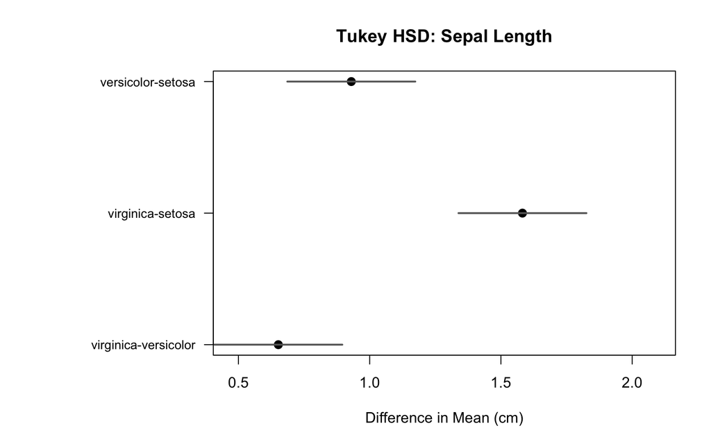

```r
plot_tukey_clean(tukey_sl, "Sepal Length", "cm")
```

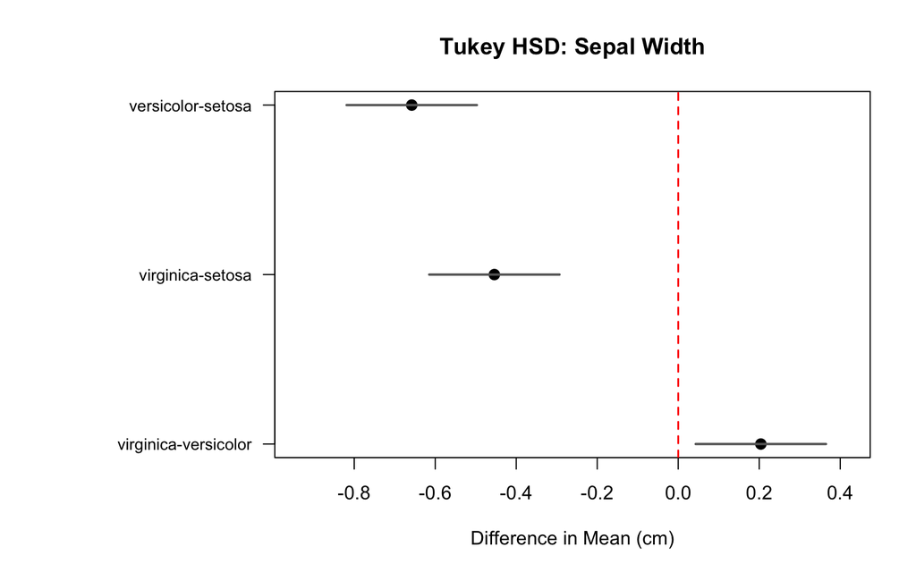

```r
plot_tukey_clean(tukey_sw, "Sepal Width", "cm")
```

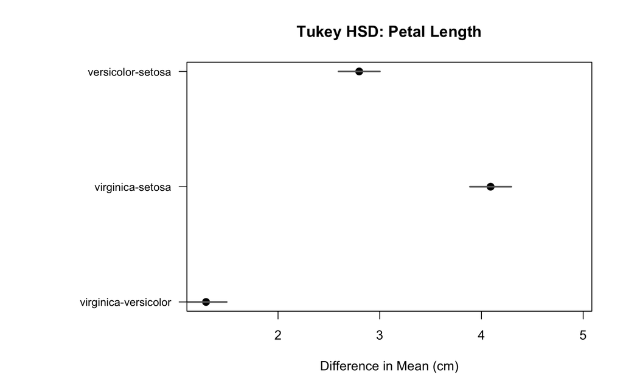

```r
plot_tukey_clean(tukey_pl, "Petal Length", "cm")
```

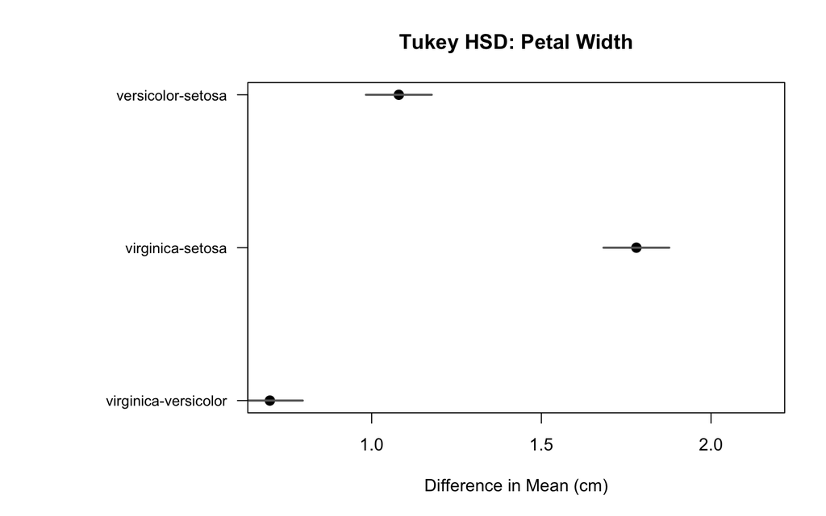

```r
plot_tukey_clean(tukey_pw, "Petal Width", "cm")
```

```r
# Reset margins
par(mar = c(5, 4, 4, 2))
```

The Tukey HSD results indicate significant differences between species for all measured variables (all p-values < 0.001), with the exception of the difference between versicolor and virginica in sepal width (p = 0.009), which remains significant after multiple comparison adjustment.

# MANOVA Analysis

Multivariate analysis of variance was conducted to examine species differences across all four morphological variables simultaneously.

```r
# MANOVA with Pillai's trace
manova_model <- manova(
  cbind(Sepal.Length, Sepal.Width, Petal.Length, Petal.Width) ~ Species,
  data = iris
)

# Summary with Pillai test statistic
manova_summary <- summary(manova_model, test = "Pillai")
print(manova_summary)
```

```
##            Df Pillai approx F num Df den Df    Pr(>F)
## Species     2 1.1919   53.466      8    290 < 2.2e-16 ***
## Residuals 147
## ---
## Signif. codes:  0 '***' 0.001 '**' 0.01 '*' 0.05 '.' 0.1 ' ' 1
```

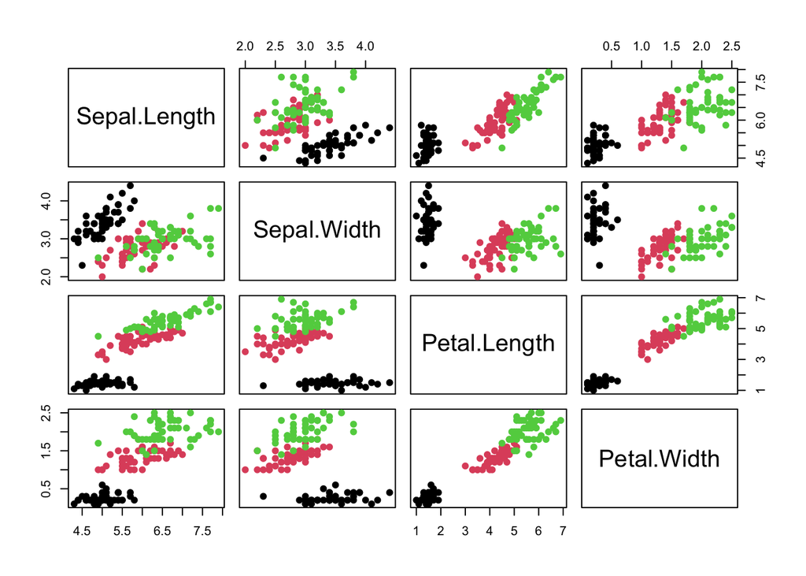

```r
pairs(iris[,1:4], col=as.numeric(iris$Species), pch=19)
```

The MANOVA results indicate a highly significant multivariate effect of species on the combination of morphological variables (Pillai’s trace), confirming that species groups differ significantly across the measured characteristics.

# Linear Discriminant Analysis (LDA)

Linear discriminant analysis was conducted to determine the linear combinations of variables that best separate the three species.

```r
# LDA model
lda_model <- lda(
  Species ~ Sepal.Length + Sepal.Width + Petal.Length + Petal.Width,
  data = iris
)

# Display LDA model summary
print(lda_model)
```

```
## Call:
## lda(Species ~ Sepal.Length + Sepal.Width + Petal.Length + Petal.Width,
##     data = iris)
##
## Prior probabilities of groups:
##     setosa versicolor  virginica
##  0.3333333  0.3333333  0.3333333
##
## Group means:
##            Sepal.Length Sepal.Width Petal.Length Petal.Width
## setosa            5.006       3.428        1.462       0.246
## versicolor        5.936       2.770        4.260       1.326
## virginica         6.588       2.974        5.552       2.026
##
## Coefficients of linear discriminants:
##                     LD1         LD2
## Sepal.Length  0.8293776 -0.02410215
## Sepal.Width   1.5344731 -2.16452123
## Petal.Length -2.2012117  0.93192121
## Petal.Width  -2.8104603 -2.83918785
##
## Proportion of trace:
##    LD1    LD2
## 0.9912 0.0088
```

```r
# Generate predictions
lda_predictions <- predict(lda_model, iris)

# Create results data frame
lda_results <- data.frame(
  observed = iris$Species,
  predicted = lda_predictions$class,
  LD1 = lda_predictions$x[, 1],
  LD2 = lda_predictions$x[, 2]
)

# Classification accuracy
accuracy <- mean(lda_results$observed == lda_results$predicted)
cat("Classification accuracy:", round(accuracy * 100, 2), "%\n")
```

```
## Classification accuracy: 98 %
```

```r
# Confusion matrix
cat("\nConfusion Matrix:\n")
```

```
##
## Confusion Matrix:
```

```r
table(Observed = lda_results$observed, Predicted = lda_results$predicted)
```

```
##             Predicted
## Observed     setosa versicolor virginica
##   setosa         50          0         0
##   versicolor      0         48         2
##   virginica       0          1        49
```

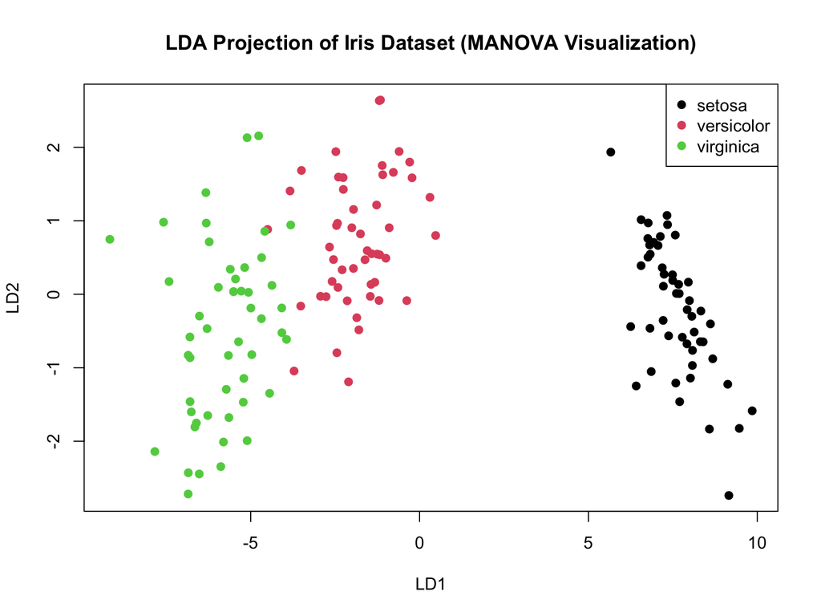

```r
# Plot LDA results
plot(
  lda_results$LD1, lda_results$LD2,
  col = as.numeric(lda_results$observed),
  pch = 19,
  xlab = "LD1",
  ylab = "LD2",
  main = "LDA Projection of Iris Dataset (MANOVA Visualization)"
)
legend(
  "topright",
  legend = levels(iris$Species),
  col = 1:3,
  pch = 19
)
```

# Discussion

The supplemental analyses confirm and extend the findings from the initial analysis. All four morphological variables show significant species differences in univariate tests, with Tukey HSD identifying specific pairwise comparisons. The MANOVA confirms significant multivariate differences between species, and LDA demonstrates high classification accuracy (98%), indicating that the measured variables effectively distinguish between the three Iris species.

The high classification accuracy from LDA suggests that the morphological differences between species are substantial and consistent, which aligns with the large effect sizes observed in the post-hoc tests. These results provide a more comprehensive understanding of the species differences in the Iris dataset than univariate analyses alone.